# Final Project DSC UNAIR

Exploratory Data Analysis of Titanic Passengers in R

Khoirunnisa Alfadistya

[figure not shown]

```r
knitr::include_graphics("C:/Users/Khoirunnisa A/Pictures/dsi_logo.png")
```

Misi “*Final Project*” dari *Data Science Club* UNAIR kelas R - Statistika yaitu melakukan Analisis Data Eksplotori pada data penumpang (*passanger*) dari kapal Titanic. Data yang digunakan disajikan dalam tabel berikut.

### Titanic Dataset

```r
datatable(titanic)
```

|  | PassengerId | Survived | Pclass | Name | Sex | Age | SibSp | Parch | Ticket | Fare | Cabin | Embarked |
| --- | --- | --- | --- | --- | --- | --- | --- | --- | --- | --- | --- | --- |
| 1 | 1 | 0 | 3 | Braund, Mr. Owen Harris | male | 22 | 1 | 0 | A/5 21171 | 7.25 |  | S |
| 2 | 2 | 1 | 1 | Cumings, Mrs. John Bradley (Florence Briggs Thayer) | female | 38 | 1 | 0 | PC 17599 | 71.2833 | C85 | C |
| 3 | 3 | 1 | 3 | Heikkinen, Miss. Laina | female | 26 | 0 | 0 | STON/O2. 3101282 | 7.925 |  | S |
| 4 | 4 | 1 | 1 | Futrelle, Mrs. Jacques Heath (Lily May Peel) | female | 35 | 1 | 0 | 113803 | 53.1 | C123 | S |
| 5 | 5 | 0 | 3 | Allen, Mr. William Henry | male | 35 | 0 | 0 | 373450 | 8.05 |  | S |
| 6 | 6 | 0 | 3 | Moran, Mr. James | male |  | 0 | 0 | 330877 | 8.4583 |  | Q |
| 7 | 7 | 0 | 1 | McCarthy, Mr. Timothy J | male | 54 | 0 | 0 | 17463 | 51.8625 | E46 | S |
| 8 | 8 | 0 | 3 | Palsson, Master. Gosta Leonard | male | 2 | 3 | 1 | 349909 | 21.075 |  | S |
| 9 | 9 | 1 | 3 | Johnson, Mrs. Oscar W (Elisabeth Vilhelmina Berg) | female | 27 | 0 | 2 | 347742 | 11.1333 |  | S |
| 10 | 10 | 1 | 2 | Nasser, Mrs. Nicholas (Adele Achem) | female | 14 | 1 | 0 | 237736 | 30.0708 |  | C |

[output cut: 881 more lines]

dengan keterangan variabel sebagai berikut :

| Variabel | Keterangan |
| --- | --- |
| PassengerId | Nomor Id penumpang (*type should be integers*) |
| Survived | Penumpang yang berhasil *survived* atau tidak |
| Pclass | kelas *Travel* |
| Name | Nama penumpang |
| Sex | Jenis Kelamin |
| SibSp | Jumlah Saudara / Pasangan dalam kapal |
| Parch | Jumlah Orangtua / Anak dalam kapal |
| Ticket | Nomor tiket |
| Fare | Tarif penumpang |
| Cabin | Nomor cabin |
| Embarked | Pelabuhan pemberangkatan (C - Cherbourg, S - Southampton, Q = Queenstown) |

untuk melakukan analisis data eksploratori pada data penumpang Titanic ini, perlu dilakukan beberapa tahapan analisis, yaitu sebagai berikut :

# 1. Eksplorasi ringkasan data (*summary*)

Berikut adalah tabel ringkasan statistik dasar untuk data penumpang Titanic

```r
summary(titanic)
```

```
##   PassengerId       Survived          Pclass
##  Min.   :  1.0   Min.   :0.0000   Min.   :1.000
##  1st Qu.:223.5   1st Qu.:0.0000   1st Qu.:2.000
##  Median :446.0   Median :0.0000   Median :3.000
##  Mean   :446.0   Mean   :0.3838   Mean   :2.309
##  3rd Qu.:668.5   3rd Qu.:1.0000   3rd Qu.:3.000
##  Max.   :891.0   Max.   :1.0000   Max.   :3.000
##
##                                     Name         Sex           Age
##  Abbing, Mr. Anthony                  :  1   female:314   Min.   : 0.42
##  Abbott, Mr. Rossmore Edward          :  1   male  :577   1st Qu.:20.12
##  Abbott, Mrs. Stanton (Rosa Hunt)     :  1                Median :28.00
##  Abelson, Mr. Samuel                  :  1                Mean   :29.70
##  Abelson, Mrs. Samuel (Hannah Wizosky):  1                3rd Qu.:38.00
##  Adahl, Mr. Mauritz Nils Martin       :  1                Max.   :80.00
##  (Other)                              :885                NA's   :177
##      SibSp           Parch             Ticket         Fare
##  Min.   :0.000   Min.   :0.0000   1601    :  7   Min.   :  0.00
##  1st Qu.:0.000   1st Qu.:0.0000   347082  :  7   1st Qu.:  7.91
##  Median :0.000   Median :0.0000   CA. 2343:  7   Median : 14.45
##  Mean   :0.523   Mean   :0.3816   3101295 :  6   Mean   : 32.20
##  3rd Qu.:1.000   3rd Qu.:0.0000   347088  :  6   3rd Qu.: 31.00
##  Max.   :8.000   Max.   :6.0000   CA 2144 :  6   Max.   :512.33
##                                   (Other) :852
##          Cabin     Embarked
##             :687    :  2
##  B96 B98    :  4   C:168
##  C23 C25 C27:  4   Q: 77
##  G6         :  4   S:644
##  C22 C26    :  3
##  D          :  3
##  (Other)    :186
```

# 2. Cek *Missing Value*

Berdasarkan langkah sebelumnya, dalam ringkasan data titanic masih diperoleh nilai missing yaitu berupa nilai NA’s pada data *Age* atau usia penumpang. Sehingga perlu dilakukan pengecekan missing value dengan langkah sebagai berikut:

### Jumlah missing value

```r
sum(is.na(titanic))
```

```
## [1] 177
```

### Plot missing value

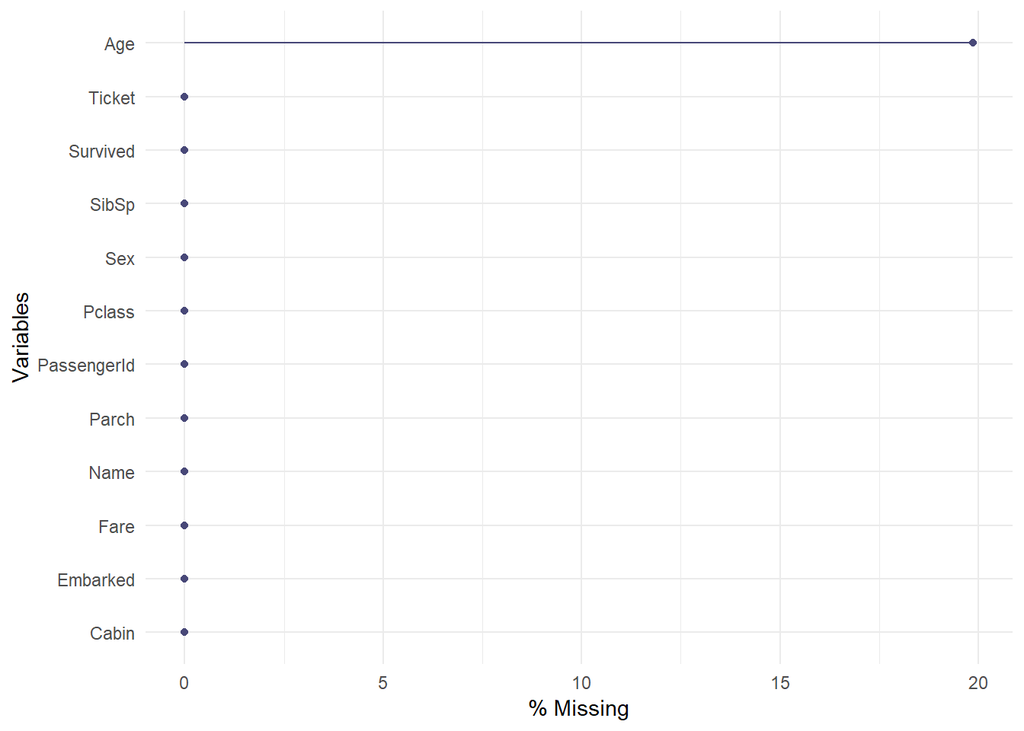

```r
library(naniar)
gg_miss_var(titanic, show_pct = TRUE)
```

Berdasarkan plot tersebut, dapat diketahui bahwa terdapat nilai yang hilang atau *missing value* pada variabel *Age*. Dengan demikian perlu dilakukan tindakan untuk mengatasi adanya *missing value* tersebut agar dapat dilakukan analisis statistik lebih lanjut. Berikut adalah cara mengatasi *missing value* dengan mengganti nilai yang hilang dengan rata-rata variabel *Age*.

```r
titanic$Age=impute(titanic$Age,mean)
```

Dengan demikian, diperoleh data yang dapat dianalisis lebih lanjut adalah sebagai berikut :

```r
datatable(titanic)
```

|  | PassengerId | Survived | Pclass | Name | Sex | Age | SibSp | Parch | Ticket | Fare | Cabin | Embarked |
| --- | --- | --- | --- | --- | --- | --- | --- | --- | --- | --- | --- | --- |
| 1 | 1 | 0 | 3 | Braund, Mr. Owen Harris | male | 22 | 1 | 0 | A/5 21171 | 7.25 |  | S |
| 2 | 2 | 1 | 1 | Cumings, Mrs. John Bradley (Florence Briggs Thayer) | female | 38 | 1 | 0 | PC 17599 | 71.2833 | C85 | C |
| 3 | 3 | 1 | 3 | Heikkinen, Miss. Laina | female | 26 | 0 | 0 | STON/O2. 3101282 | 7.925 |  | S |
| 4 | 4 | 1 | 1 | Futrelle, Mrs. Jacques Heath (Lily May Peel) | female | 35 | 1 | 0 | 113803 | 53.1 | C123 | S |
| 5 | 5 | 0 | 3 | Allen, Mr. William Henry | male | 35 | 0 | 0 | 373450 | 8.05 |  | S |
| 6 | 6 | 0 | 3 | Moran, Mr. James | male | 29.6991176470588 | 0 | 0 | 330877 | 8.4583 |  | Q |
| 7 | 7 | 0 | 1 | McCarthy, Mr. Timothy J | male | 54 | 0 | 0 | 17463 | 51.8625 | E46 | S |
| 8 | 8 | 0 | 3 | Palsson, Master. Gosta Leonard | male | 2 | 3 | 1 | 349909 | 21.075 |  | S |
| 9 | 9 | 1 | 3 | Johnson, Mrs. Oscar W (Elisabeth Vilhelmina Berg) | female | 27 | 0 | 2 | 347742 | 11.1333 |  | S |
| 10 | 10 | 1 | 2 | Nasser, Mrs. Nicholas (Adele Achem) | female | 14 | 1 | 0 | 237736 | 30.0708 |  | C |

[output cut: 881 more lines]

# 3. Exploratory Data Analysis (EDA)

Berikut adalah langkah - langkah dalam melakukan EDA :

### Visualisasi data

#### Gender

##### Proporsi gender umum

```r
prop.sex <- prop.table(table(titanic$Sex))
print(prop.sex)
```

```
##
##   female     male
## 0.352413 0.647587
```

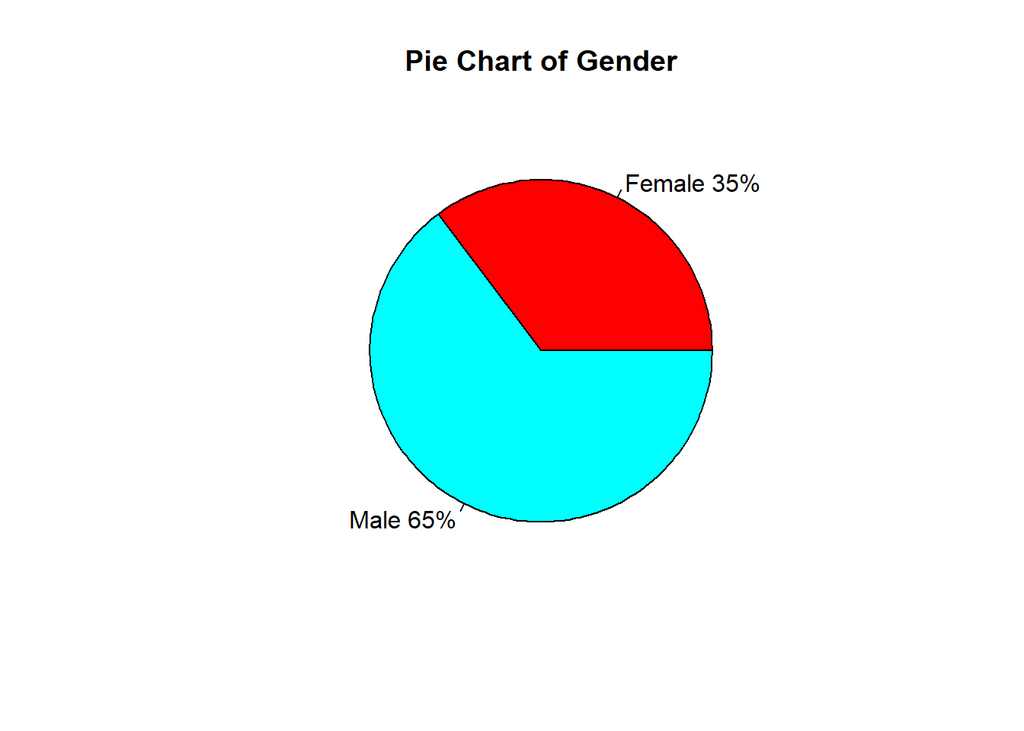

```r
value1=prop.sex*100
group1=c("Female","Male")
slices <- prop.sex
lbls <- group1
pct <- round(slices/sum(slices)*100)
lbls <- paste(lbls, pct) # add percents to labels
lbls <- paste(lbls,"%",sep="") # ad % to labels
pie(slices,labels = lbls, col=rainbow(length(lbls)),
   main="Pie Chart of Gender")
```

```r
prop.class <-  prop.table(table(titanic$Pclass))
print(prop.class)
```

```
##
##         1         2         3
## 0.2424242 0.2065095 0.5510662
```

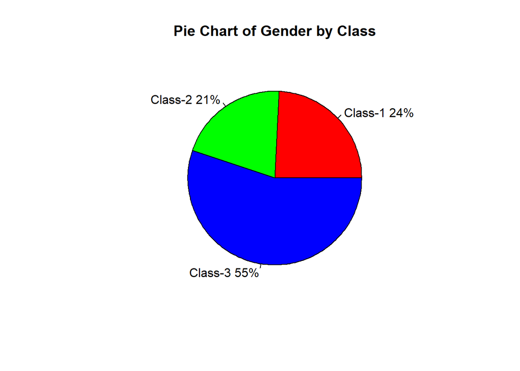

```r
value2=prop.class*100
group2=c("Class-1","Class-2","Class-3")
slices <- prop.class
lbls <- group2
pct <- round(slices/sum(slices)*100)
lbls <- paste(lbls, pct) # add percents to labels
lbls <- paste(lbls,"%",sep="") # ad % to labels
pie(slices,labels = lbls, col=rainbow(length(lbls)),
   main="Pie Chart of Gender by Class")
```

#### Pelabuhan Pemberangkatan

Visualisasi sebaran pelabuhan pemberangkatan penumpang Titanic

```r
prop.embarked <- prop.table(table(titanic$Embarked))
print(prop.embarked)
```

```
##
##                       C           Q           S
## 0.002244669 0.188552189 0.086419753 0.722783389
```

[figure not shown]

```r
value3=prop.embarked*100
group3=c("Cherbourg","Southampton","Queenstown")
slices <- prop.embarked
lbls <- group3
pct <- round(slices/sum(slices)*100)
lbls <- paste(lbls, pct) # add percents to labels
lbls <- paste(lbls,"%",sep="") # ad % to labels
pie(slices,labels = lbls, col=rainbow(length(lbls)),
   main="Pie Chart of Embarked")
```